# SPPH 504 Section 007 Lab (5.3) Propensity score weighting (Inverse probability weighting) in NHANES

Ehsan Karim, ehsan.karim@ubc.ca

01 May 2020

# 1 Pre-processing

## 1.1 load data

```r
load(file="data/analyticNHANES78.RData")
analytic.data <- DT9a
```

## 1.2 Set seed

```r
set.seed(123)
```

# 2 DuGoff, E. H., Schuler, M., & Stuart, E. A. (2014)

Fitting propensity score model

## 2.1 Step 1

Specify PS model

```r
# response = exposure variable
# independent variables = baseline covariates
ps.formula <- as.formula(I(arthritis.type==
                             "Rheumatoid arthritis") ~ gender+bmi+
                           diabetes+smoke+age+race+born+education+
                           marriage+annualincome+physical.activity+
                           medical.access+blood.pressure+healthy.diet+
                           covered.health+
                           PSU+strata+interview.weight)
PS.fit <- glm(ps.formula,
                family=binomial(logit), data=analytic.data)
# extract propensity scores
analytic.data$PS <- predict(PS.fit, type="response")
# summarize propensity scores
summary(analytic.data$PS)
```

```
##     Min.  1st Qu.   Median     Mean  3rd Qu.     Max.
## 0.001373 0.014070 0.032528 0.064414 0.087050 0.618220
```

```r
# summarize propensity scores by exposure group
tapply(analytic.data$PS, analytic.data$arthritis.type, summary)
```

```
## $`Non-arthritis`
##     Min.  1st Qu.   Median     Mean  3rd Qu.     Max.
## 0.001373 0.013465 0.029988 0.058206 0.075126 0.597606
##
## $`Rheumatoid arthritis`
##     Min.  1st Qu.   Median     Mean  3rd Qu.     Max.
## 0.005355 0.072551 0.132798 0.154578 0.203229 0.618220
```

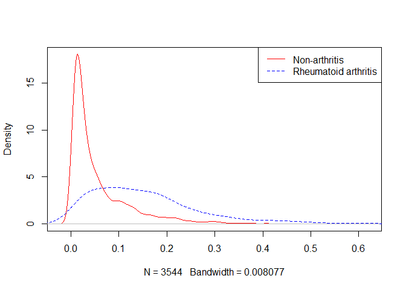

```r
# plot propensity scores by exposure group
plot(density(analytic.data$PS[analytic.data$arthritis.type==
                                "Non-arthritis"]), col = "red", main = "")
lines(density(analytic.data$PS[analytic.data$arthritis.type==
                                 "Rheumatoid arthritis"]),
      col = "blue", lty = 2)
legend("topright", c("Non-arthritis","Rheumatoid arthritis"),
       col = c("red", "blue"), lty=1:2)
```

## 2.2 ATE

### 2.2.1 Step 2

Convert propensity scores to IPW

```r
analytic.data$IPW <- ifelse(analytic.data$arthritis.type==
                              "Rheumatoid arthritis",
                            1/analytic.data$PS,
                            1/(1-analytic.data$PS))
analytic.data$combined.weight <- analytic.data$IPW *
                                 analytic.data$interview.weight

summary(analytic.data$combined.weight)
```

```
##     Min.  1st Qu.   Median     Mean  3rd Qu.     Max.
##     3951    20611    29372    81381    68504 17037036
```

```r
tapply(analytic.data$combined.weight, analytic.data$arthritis.type, summary)
```

```
## $`Non-arthritis`
##    Min. 1st Qu.  Median    Mean 3rd Qu.    Max.
##    3951   19905   28158   41101   61338  166053
##
## $`Rheumatoid arthritis`
##     Min.  1st Qu.   Median     Mean  3rd Qu.     Max.
##    13640    58146   145279   666434   398786 17037036
```

### 2.2.2 Step 3

Balance checking

```r
require(tableone)
baselinevars <- c("gender", "bmi", "diabetes", "smoke", "age",
                  "race", "born", "education", "marriage",
                  "annualincome", "physical.activity", "medical.access",
                  "blood.pressure", "healthy.diet", "covered.health")
tab1 <- CreateTableOne(strata = "arthritis.type", vars = baselinevars,
                       data = analytic.data, test = FALSE)
print(tab1, smd = TRUE)
```

```
##                           Stratified by arthritis.type
##                            Non-arthritis Rheumatoid arthritis SMD
##   n                        3544          244
##   gender = Female (%)      1713 (48.3)   137 (56.1)            0.157
##   bmi = (25,80] (%)        2430 (68.6)   182 (74.6)            0.134
##   diabetes = Yes (%)        298 ( 8.4)    28 (11.5)            0.103
##   smoke = Yes (%)          1549 (43.7)   135 (55.3)            0.234
##   age (%)                                                      0.826
##      (19.9,50]             2276 (64.2)    64 (26.2)
##      (50,70]                894 (25.2)   127 (52.0)
##      (70,81]                374 (10.6)    53 (21.7)
##   race (%)                                                     0.293
##      White                 1544 (43.6)    99 (40.6)
##      Black                  732 (20.7)    80 (32.8)
##      Other                 1268 (35.8)    65 (26.6)
##   born = USborn (%)        2570 (72.5)   197 (80.7)            0.195
##   education (%)                                                0.112
##      School                 396 (11.2)    32 (13.1)
##      College               1673 (47.2)   102 (41.8)
##      High.School           1475 (41.6)   110 (45.1)
##   marriage = Married (%)   2160 (60.9)   117 (48.0)            0.263
##   annualincome (%)                                             0.523
##      <20k                   698 (19.7)    98 (40.2)
##      20kto54k              1483 (41.8)    97 (39.8)
##      55k+                  1363 (38.5)    49 (20.1)
##   physical.activity (%)                                        0.275
##      No                    1971 (55.6)   166 (68.0)
##      High                   768 (21.7)    32 (13.1)
##      Moderate               805 (22.7)    46 (18.9)
##   medical.access = Yes (%) 2882 (81.3)   232 (95.1)            0.437
##   blood.pressure = Yes (%)  919 (25.9)   138 (56.6)            0.655
##   healthy.diet (%)                                             0.167
##      Poor                   193 ( 5.4)    23 ( 9.4)
##      Fair                   819 (23.1)    61 (25.0)
##      Good                  2532 (71.4)   160 (65.6)
##   covered.health = Yes (%) 2522 (71.2)   207 (84.8)            0.335
```

```r
require(survey)
analytic.design <- svydesign(id=~PSU,weights=~combined.weight,
                             strata=~strata,
                             data=analytic.data, nest=TRUE)
tab1m <- svyCreateTableOne(strata = "arthritis.type",
                           vars = baselinevars,
                           data = analytic.design, test = FALSE)
print(tab1m, smd = TRUE)
```

```
##                           Stratified by arthritis.type
##                            Non-arthritis       Rheumatoid arthritis SMD
##   n                        145662517.4         162609807.8
##   gender = Female (%)       72559831.3 (49.8)   73567259.3 (45.2)    0.092
##   bmi = (25,80] (%)         95616077.3 (65.6)  131931617.6 (81.1)    0.356
##   diabetes = Yes (%)         8063624.4 ( 5.5)   10611451.7 ( 6.5)    0.042
##   smoke = Yes (%)           64250081.9 (44.1)   60024644.5 (36.9)    0.147
##   age (%)                                                            0.112
##      (19.9,50]             102303715.2 (70.2)  122168028.6 (75.1)
##      (50,70]                34053012.2 (23.4)   32362663.4 (19.9)
##      (70,81]                 9305790.0 ( 6.4)    8079115.8 ( 5.0)
##   race (%)                                                           0.347
##      White                  97580611.0 (67.0)  132476071.9 (81.5)
##      Black                  17373651.9 (11.9)    8314628.8 ( 5.1)
##      Other                  30708254.5 (21.1)   21819107.2 (13.4)
##   born = USborn (%)        119616359.5 (82.1)  146757135.3 (90.3)    0.237
##   education (%)                                                      0.143
##      School                  7666888.2 ( 5.3)    7230910.4 ( 4.4)
##      College                83058422.1 (57.0)  104066245.8 (64.0)
##      High.School            54937207.1 (37.7)   51312651.6 (31.6)
##   marriage = Married (%)    92397929.1 (63.4)  119841521.5 (73.7)    0.222
##   annualincome (%)                                                   0.234
##      <20k                   20394987.8 (14.0)   22664246.5 (13.9)
##      20kto54k               52214232.6 (35.8)   41532948.4 (25.5)
##      55k+                   73053296.9 (50.2)   98412613.0 (60.5)
##   physical.activity (%)                                              0.201
##      No                     75840027.9 (52.1)   77315821.1 (47.5)
##      High                   32444948.2 (22.3)   50385871.7 (31.0)
##      Moderate               37377541.3 (25.7)   34908115.1 (21.5)
##   medical.access = Yes (%) 121997789.4 (83.8)  148482441.6 (91.3)    0.230
##   blood.pressure = Yes (%)  34065712.9 (23.4)   37720348.5 (23.2)    0.004
##   healthy.diet (%)                                                   0.074
##      Poor                    7778173.7 ( 5.3)   11048198.6 ( 6.8)
##      Fair                   32374185.3 (22.2)   38388938.6 (23.6)
##      Good                  105510158.4 (72.4)  113172670.7 (69.6)
##   covered.health = Yes (%) 114065019.3 (78.3)  129990519.6 (79.9)    0.040
```

### 2.2.3 Step 4

Estimate the effect of treatment on outcomes

```r
require(survey)
# setup the design with survey features
out.formula <- as.formula(I(heart.attack=="Yes") ~ arthritis.type)
sfit <- svyglm(out.formula,family=quasibinomial, design = analytic.design)
require(jtools)
summ(sfit, exp = TRUE, confint = TRUE)
```

| Observations | 3788 |
| --- | --- |
| Dependent variable | I(heart.attack == “Yes”) |
| Type | Survey-weighted generalized linear model |
| Family | quasibinomial |
| Link | logit |

| Pseudo-R² (Cragg-Uhler) | 0.00 |
| --- | --- |
| Pseudo-R² (McFadden) | 0.00 |
| AIC | NA |

|  | exp(Est.) | 2.5% | 97.5% | t val. | p |
| --- | --- | --- | --- | --- | --- |
| (Intercept) | 0.02 | 0.01 | 0.03 | -29.77 | 0.00 |
| arthritis.typeRheumatoid arthritis | 1.55 | 0.63 | 3.82 | 0.95 | 0.36 |

Standard errors: Robust

### 2.2.4 More refined analysis

Note that, in the weighted data, there were several variables where SMD was $>$ .2. In this case, general strategy is to reformulate the PS model and re-do steps 1-3.

If all efforts fail, then adjust for potentially imbalanced covariates (assuming the new cut-point to be $>$ .2).

```r
out.formula <- as.formula(I(heart.attack=="Yes") ~ arthritis.type +
                            bmi+race+born+marriage+annualincome+
                            physical.activity+medical.access)
sfit <- svyglm(out.formula,family=quasibinomial, design = analytic.design)
require(jtools)
summ(sfit, exp = TRUE, confint = TRUE)
```

| Observations | 3788 |
| --- | --- |
| Dependent variable | I(heart.attack == “Yes”) |
| Type | Survey-weighted generalized linear model |
| Family | quasibinomial |
| Link | logit |

| Pseudo-R² (Cragg-Uhler) | 0.11 |
| --- | --- |
| Pseudo-R² (McFadden) | 0.14 |
| AIC | NA |

|  | exp(Est.) | 2.5% | 97.5% | t val. | p |
| --- | --- | --- | --- | --- | --- |
| (Intercept) | 0.02 | 0.00 | 0.23 | -3.14 | 0.03 |
| arthritis.typeRheumatoid arthritis | 1.86 | 0.79 | 4.43 | 1.41 | 0.22 |
| bmi(25,80] | 0.67 | 0.29 | 1.54 | -0.94 | 0.39 |
| raceBlack | 2.07 | 1.05 | 4.09 | 2.10 | 0.09 |
| raceOther | 2.02 | 0.49 | 8.29 | 0.98 | 0.37 |
| bornUSborn | 2.43 | 0.57 | 10.39 | 1.20 | 0.28 |
| marriageMarried | 1.58 | 0.58 | 4.36 | 0.89 | 0.41 |
| annualincome20kto54k | 0.25 | 0.09 | 0.68 | -2.73 | 0.04 |
| annualincome55k+ | 0.06 | 0.02 | 0.19 | -4.79 | 0.00 |
| physical.activityHigh | 1.55 | 0.39 | 6.10 | 0.62 | 0.56 |
| physical.activityModerate | 0.67 | 0.26 | 1.74 | -0.81 | 0.45 |
| medical.accessYes | 1.35 | 0.24 | 7.68 | 0.34 | 0.75 |

Standard errors: Robust

## 2.3 ATT

### 2.3.1 Step 2

Convert propensity scores to IPW.ATT

```r
analytic.data$IPW.ATT <- ifelse(analytic.data$arthritis.type==
                              "Rheumatoid arthritis",
                            1,
                            analytic.data$PS/(1-analytic.data$PS))
analytic.data$combined.weight <- analytic.data$IPW.ATT *
                                 analytic.data$interview.weight

summary(analytic.data$combined.weight)
```

```
##      Min.   1st Qu.    Median      Mean   3rd Qu.      Max.
##     19.01    491.77   1058.75   3465.22   2784.62 117656.74
```

```r
tapply(analytic.data$combined.weight, analytic.data$arthritis.type, summary)
```

```
## $`Non-arthritis`
##     Min.  1st Qu.   Median     Mean  3rd Qu.     Max.
##    19.01   459.68   968.40  1863.21  2242.20 36965.31
##
## $`Rheumatoid arthritis`
##    Min. 1st Qu.  Median    Mean 3rd Qu.    Max.
##    4078   10342   20226   26734   28459  117657
```

### 2.3.2 Step 3

Balance checking

```r
analytic.design <- svydesign(id=~PSU,weights=~combined.weight,
                             strata=~strata,
                             data=analytic.data, nest=TRUE)
tab1m <- svyCreateTableOne(strata = "arthritis.type",
                           vars = baselinevars,
                           data = analytic.design, test = FALSE)
print(tab1m, smd = TRUE)
```

```
##                           Stratified by arthritis.type
##                            Non-arthritis     Rheumatoid arthritis SMD
##   n                        6603230.8         6523006.1
##   gender = Female (%)      3875923.1 (58.7)  3788834.0 (58.1)      0.012
##   bmi = (25,80] (%)        4834679.8 (73.2)  5213690.4 (79.9)      0.159
##   diabetes = Yes (%)        504026.2 ( 7.6)   589128.3 ( 9.0)      0.051
##   smoke = Yes (%)          3662585.3 (55.5)  3357917.3 (51.5)      0.080
##   age (%)                                                          0.166
##      (19.9,50]             2285883.8 (34.6)  2769791.7 (42.5)
##      (50,70]               3218742.4 (48.7)  2719825.1 (41.7)
##      (70,81]               1098604.6 (16.6)  1033389.3 (15.8)
##   race (%)                                                         0.101
##      White                 4176581.4 (63.3)  4434100.5 (68.0)
##      Black                 1363697.8 (20.7)  1204191.0 (18.5)
##      Other                 1062951.6 (16.1)   884714.5 (13.6)
##   born = USborn (%)        5784165.6 (87.6)  5855486.8 (89.8)      0.069
##   education (%)                                                    0.067
##      School                 429031.8 ( 6.5)   535774.9 ( 8.2)
##      College               3365788.2 (51.0)  3302838.0 (50.6)
##      High.School           2808410.8 (42.5)  2684393.2 (41.2)
##   marriage = Married (%)   3470954.6 (52.6)  3576055.0 (54.8)      0.045
##   annualincome (%)                                                 0.007
##      <20k                  2067380.3 (31.3)  2057956.0 (31.5)
##      20kto54k              2625529.2 (39.8)  2596796.9 (39.8)
##      55k+                  1910321.3 (28.9)  1868253.2 (28.6)
##   physical.activity (%)                                            0.025
##      No                    4078179.6 (61.8)  3977222.5 (61.0)
##      High                   969627.1 (14.7)  1014480.1 (15.6)
##      Moderate              1555424.0 (23.6)  1531303.5 (23.5)
##   medical.access = Yes (%) 6278775.5 (95.1)  6275869.7 (96.2)      0.055
##   blood.pressure = Yes (%) 3311607.0 (50.2)  3484095.6 (53.4)      0.065
##   healthy.diet (%)                                                 0.078
##      Poor                   606102.7 ( 9.2)   738721.4 (11.3)
##      Fair                  1637595.5 (24.8)  1489982.7 (22.8)
##      Good                  4359532.6 (66.0)  4294302.1 (65.8)
##   covered.health = Yes (%) 5728034.2 (86.7)  5604130.0 (85.9)      0.024
```

### 2.3.3 Step 4

Estimate the effect of treatment on outcomes

```r
out.formula <- as.formula(I(heart.attack=="Yes") ~ arthritis.type)
sfit <- svyglm(out.formula,family=quasibinomial, design = analytic.design)
require(jtools)
summ(sfit, exp = TRUE, confint = TRUE)
```

| Observations | 3788 |
| --- | --- |
| Dependent variable | I(heart.attack == “Yes”) |
| Type | Survey-weighted generalized linear model |
| Family | quasibinomial |
| Link | logit |

| Pseudo-R² (Cragg-Uhler) | 0.00 |
| --- | --- |
| Pseudo-R² (McFadden) | 0.00 |
| AIC | NA |

|  | exp(Est.) | 2.5% | 97.5% | t val. | p |
| --- | --- | --- | --- | --- | --- |
| (Intercept) | 0.05 | 0.03 | 0.08 | -14.56 | 0.00 |
| arthritis.typeRheumatoid arthritis | 1.41 | 0.75 | 2.63 | 1.06 | 0.30 |

Standard errors: Robust

### 2.3.4 More refined analysis

Note that, in the weighted data, there were no variables where SMD was $>$ .2. In this case, we do not need repeating the steps 1-3.

# 3 Ridgeway G., Kovalchik S. A., Griffin B. A. and Kabeto M. U. (2015).

Ridgeway et al. suggested that the survey weights should be incorporated at both stages of the propensity score analysis (PS+Outcome, as design variables): “Through simulation we showed that across a range of scenarios the most robust strategy is to use the sampling weights in the propensity score model and to use the sampling weight times the propensity score weight as the weight in the final outcome analysis”.

## 3.1 Step 1

Specify PS model

```r
ps.formula <- as.formula(I(arthritis.type==
                             "Rheumatoid arthritis") ~ gender+bmi+
                           diabetes+smoke+age+race+born+education+
                           marriage+annualincome+physical.activity+
                           medical.access+blood.pressure+healthy.diet+
                           covered.health)
require(survey)
# specify design
analytic.design <- svydesign(id=~PSU,weights=~interview.weight,
                             strata=~strata,
                             data=analytic.data, nest=TRUE)
ps.fit <- svyglm(ps.formula, design=analytic.design, family=quasibinomial)
analytic.data$PS <- fitted(ps.fit)
# summarize propensity scores
summary(analytic.data$PS)
```

```
##      Min.   1st Qu.    Median      Mean   3rd Qu.      Max.
## 0.0007958 0.0127072 0.0298116 0.0575080 0.0741030 0.6287508
```

```r
# summarize propensity scores by exposure group
tapply(analytic.data$PS, analytic.data$arthritis.type, summary)
```

```
## $`Non-arthritis`
##      Min.   1st Qu.    Median      Mean   3rd Qu.      Max.
## 0.0007958 0.0121408 0.0273449 0.0522868 0.0652718 0.6180696
##
## $`Rheumatoid arthritis`
##    Min. 1st Qu.  Median    Mean 3rd Qu.    Max.
## 0.00412 0.05841 0.10311 0.13334 0.18258 0.62875
```

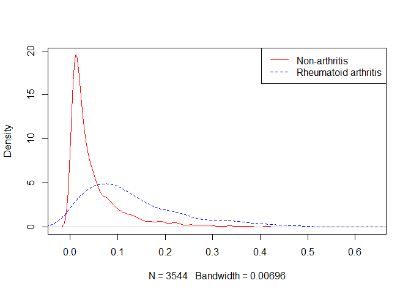

```r
# plot propensity scores by exposure group
plot(density(analytic.data$PS[analytic.data$arthritis.type==
                                "Non-arthritis"]), col = "red", main = "")
lines(density(analytic.data$PS[analytic.data$arthritis.type==
                                 "Rheumatoid arthritis"]),
      col = "blue", lty = 2)
legend("topright", c("Non-arthritis","Rheumatoid arthritis"),
       col = c("red", "blue"), lty=1:2)
```

## 3.2 ATE

### 3.2.1 Step 2

Convert propensity scores to IPW

```r
analytic.data$IPW <- ifelse(analytic.data$arthritis.type==
                              "Rheumatoid arthritis",
                            1/analytic.data$PS,
                            1/(1-analytic.data$PS))
analytic.data$combined.weight <- analytic.data$IPW *
                                 analytic.data$interview.weight

summary(analytic.data$combined.weight)
```

```
##     Min.  1st Qu.   Median     Mean  3rd Qu.     Max.
##     3893    20522    29303    76754    69373 12354995
```

```r
tapply(analytic.data$combined.weight, analytic.data$arthritis.type, summary)
```

```
## $`Non-arthritis`
##    Min. 1st Qu.  Median    Mean 3rd Qu.    Max.
##    3893   19738   27964   41086   61003  166029
##
## $`Rheumatoid arthritis`
##     Min.  1st Qu.   Median     Mean  3rd Qu.     Max.
##    13132    70689   170309   594819   435053 12354995
```

### 3.2.2 Step 3

Balance checking in the weighted data

```r
baselinevars <- c("gender", "bmi", "diabetes", "smoke", "age",
                  "race", "born", "education", "marriage",
                  "annualincome", "physical.activity", "medical.access",
                  "blood.pressure", "healthy.diet", "covered.health")
analytic.design <- svydesign(id=~PSU,weights=~combined.weight,
                             strata=~strata,
                             data=analytic.data, nest=TRUE)
tab1m <- svyCreateTableOne(strata = "arthritis.type",
                           vars = baselinevars,
                           data = analytic.design, test = FALSE)
print(tab1m, smd = TRUE)
```

```
##                           Stratified by arthritis.type
##                            Non-arthritis       Rheumatoid arthritis SMD
##   n                        145609957.7         145135861.9
##   gender = Female (%)       72456484.6 (49.8)   69588712.6 (47.9)    0.036
##   bmi = (25,80] (%)         96018654.3 (65.9)  106329287.6 (73.3)    0.160
##   diabetes = Yes (%)         8174853.4 ( 5.6)    7513288.0 ( 5.2)    0.019
##   smoke = Yes (%)           63970017.8 (43.9)   58188209.1 (40.1)    0.078
##   age (%)                                                            0.133
##      (19.9,50]             102756857.9 (70.6)   93854961.6 (64.7)
##      (50,70]                33592123.7 (23.1)   41750258.7 (28.8)
##      (70,81]                 9260976.2 ( 6.4)    9530641.6 ( 6.6)
##   race (%)                                                           0.147
##      White                  97866325.9 (67.2)  103141334.9 (71.1)
##      Black                  17207883.5 (11.8)   10897242.3 ( 7.5)
##      Other                  30535748.4 (21.0)   31097284.7 (21.4)
##   born = USborn (%)        119707130.5 (82.2)  123350923.1 (85.0)    0.075
##   education (%)                                                      0.125
##      School                  7778848.9 ( 5.3)    4586711.0 ( 3.2)
##      College                83028939.7 (57.0)   89062823.7 (61.4)
##      High.School            54802169.2 (37.6)   51486327.3 (35.5)
##   marriage = Married (%)    92482473.0 (63.5)   96894710.5 (66.8)    0.068
##   annualincome (%)                                                   0.207
##      <20k                   20446929.1 (14.0)   20058939.4 (13.8)
##      20kto54k               52141359.6 (35.8)   38779249.4 (26.7)
##      55k+                   73021669.1 (50.1)   86297673.1 (59.5)
##   physical.activity (%)                                              0.095
##      No                     75725229.3 (52.0)   71108733.6 (49.0)
##      High                   32497377.5 (22.3)   38272640.1 (26.4)
##      Moderate               37387350.9 (25.7)   35754488.2 (24.6)
##   medical.access = Yes (%) 122021572.3 (83.8)  124361603.5 (85.7)    0.052
##   blood.pressure = Yes (%)  34246002.5 (23.5)   29010140.8 (20.0)    0.086
##   healthy.diet (%)                                                   0.100
##      Poor                    7951468.7 ( 5.5)    6449005.0 ( 4.4)
##      Fair                   32214833.2 (22.1)   37948231.6 (26.1)
##      Good                  105443655.8 (72.4)  100738625.3 (69.4)
##   covered.health = Yes (%) 113954497.2 (78.3)  113218019.3 (78.0)    0.006
```

### 3.2.3 Step 4

Estimate the effect of treatment on outcomes

```r
# setup the design with survey features
out.formula <- as.formula(I(heart.attack=="Yes") ~ arthritis.type)
sfit <- svyglm(out.formula,family=quasibinomial, design = analytic.design)
require(jtools)
summ(sfit, exp = TRUE, confint = TRUE)
```

| Observations | 3788 |
| --- | --- |
| Dependent variable | I(heart.attack == “Yes”) |
| Type | Survey-weighted generalized linear model |
| Family | quasibinomial |
| Link | logit |

| Pseudo-R² (Cragg-Uhler) | 0.01 |
| --- | --- |
| Pseudo-R² (McFadden) | 0.01 |
| AIC | NA |

|  | exp(Est.) | 2.5% | 97.5% | t val. | p |
| --- | --- | --- | --- | --- | --- |
| (Intercept) | 0.02 | 0.01 | 0.03 | -29.81 | 0.00 |
| arthritis.typeRheumatoid arthritis | 1.79 | 0.76 | 4.20 | 1.34 | 0.20 |

Standard errors: Robust

### 3.2.4 More refined analysis

Note that, in the weighted data, there was 1 variable where SMD was $>$ .2. In this case, general strategy is to reformulate the PS model and re-do steps 1-3.

If all efforts fail, then adjust for potentially imbalanced covariates (assuming the new cut-point to be $>$ .2).

```r
out.formula <- as.formula(I(heart.attack=="Yes") ~ arthritis.type +
                            annualincome)
sfit <- svyglm(out.formula,family=quasibinomial, design = analytic.design)
require(jtools)
summ(sfit, exp = TRUE, confint = TRUE)
```

| Observations | 3788 |
| --- | --- |
| Dependent variable | I(heart.attack == “Yes”) |
| Type | Survey-weighted generalized linear model |
| Family | quasibinomial |
| Link | logit |

| Pseudo-R² (Cragg-Uhler) | 0.08 |
| --- | --- |
| Pseudo-R² (McFadden) | 0.10 |
| AIC | NA |

|  | exp(Est.) | 2.5% | 97.5% | t val. | p |
| --- | --- | --- | --- | --- | --- |
| (Intercept) | 0.06 | 0.03 | 0.12 | -8.58 | 0.00 |
| arthritis.typeRheumatoid arthritis | 1.99 | 0.93 | 4.24 | 1.77 | 0.10 |
| annualincome20kto54k | 0.34 | 0.10 | 1.11 | -1.78 | 0.10 |
| annualincome55k+ | 0.09 | 0.04 | 0.21 | -5.64 | 0.00 |

Standard errors: Robust

## 3.3 ATT

### 3.3.1 Step 2

Convert propensity scores to IPW.ATT

```r
analytic.data$IPW.ATT <- ifelse(analytic.data$arthritis.type==
                              "Rheumatoid arthritis",
                            1,
                            analytic.data$PS/(1-analytic.data$PS))
analytic.data$combined.weight <- analytic.data$IPW.ATT *
                                 analytic.data$interview.weight

summary(analytic.data$combined.weight)
```

```
##      Min.   1st Qu.    Median      Mean   3rd Qu.      Max.
##      7.94    386.19   1009.95   3451.34   2745.63 117656.74
```

```r
tapply(analytic.data$combined.weight, analytic.data$arthritis.type, summary)
```

```
## $`Non-arthritis`
##      Min.   1st Qu.    Median      Mean   3rd Qu.      Max.
##     7.941   357.116   902.465  1848.384  2237.222 27812.202
##
## $`Rheumatoid arthritis`
##    Min. 1st Qu.  Median    Mean 3rd Qu.    Max.
##    4078   10342   20226   26734   28459  117657
```

### 3.3.2 Step 3

Balance checking

```r
analytic.design <- svydesign(id=~PSU,weights=~combined.weight,
                             strata=~strata,
                             data=analytic.data, nest=TRUE)
tab1m <- svyCreateTableOne(strata = "arthritis.type",
                           vars = baselinevars,
                           data = analytic.design, test = FALSE)
print(tab1m, smd = TRUE)
```

```
##                           Stratified by arthritis.type
##                            Non-arthritis     Rheumatoid arthritis SMD
##   n                        6550671.1         6523006.1
##   gender = Female (%)      3772576.4 (57.6)  3788834.0 (58.1)      0.010
##   bmi = (25,80] (%)        5237256.7 (79.9)  5213690.4 (79.9)      0.001
##   diabetes = Yes (%)        615255.2 ( 9.4)   589128.3 ( 9.0)      0.012
##   smoke = Yes (%)          3382521.2 (51.6)  3357917.3 (51.5)      0.003
##   age (%)                                                          0.013
##      (19.9,50]             2739026.5 (41.8)  2769791.7 (42.5)
##      (50,70]               2757853.8 (42.1)  2719825.1 (41.7)
##      (70,81]               1053790.9 (16.1)  1033389.3 (15.8)
##   race (%)                                                         0.004
##      White                 4462296.3 (68.1)  4434100.5 (68.0)
##      Black                 1197929.4 (18.3)  1204191.0 (18.5)
##      Other                  890445.4 (13.6)   884714.5 (13.6)
##   born = USborn (%)        5874936.6 (89.7)  5855486.8 (89.8)      0.003
##   education (%)                                                    0.007
##      School                 540992.6 ( 8.3)   535774.9 ( 8.2)
##      College               3336305.7 (50.9)  3302838.0 (50.6)
##      High.School           2673372.9 (40.8)  2684393.2 (41.2)
##   marriage = Married (%)   3555498.4 (54.3)  3576055.0 (54.8)      0.011
##   annualincome (%)                                                 0.020
##      <20k                  2119321.6 (32.4)  2057956.0 (31.5)
##      20kto54k              2552656.1 (39.0)  2596796.9 (39.8)
##      55k+                  1878693.5 (28.7)  1868253.2 (28.6)
##   physical.activity (%)                                            0.011
##      No                    3963381.1 (60.5)  3977222.5 (61.0)
##      High                  1022056.4 (15.6)  1014480.1 (15.6)
##      Moderate              1565233.7 (23.9)  1531303.5 (23.5)
##   medical.access = Yes (%) 6302558.4 (96.2)  6275869.7 (96.2)     <0.001
##   blood.pressure = Yes (%) 3491896.6 (53.3)  3484095.6 (53.4)      0.002
##   healthy.diet (%)                                                 0.018
##      Poor                   779397.7 (11.9)   738721.4 (11.3)
##      Fair                  1478243.5 (22.6)  1489982.7 (22.8)
##      Good                  4293030.0 (65.5)  4294302.1 (65.8)
##   covered.health = Yes (%) 5617512.1 (85.8)  5604130.0 (85.9)      0.005
```

### 3.3.3 Step 4

Estimate the effect of treatment on outcomes

```r
out.formula <- as.formula(I(heart.attack=="Yes") ~ arthritis.type)
sfit <- svyglm(out.formula,family=quasibinomial, design = analytic.design)
require(jtools)
summ(sfit, exp = TRUE, confint = TRUE)
```

| Observations | 3788 |
| --- | --- |
| Dependent variable | I(heart.attack == “Yes”) |
| Type | Survey-weighted generalized linear model |
| Family | quasibinomial |
| Link | logit |

| Pseudo-R² (Cragg-Uhler) | 0.00 |
| --- | --- |
| Pseudo-R² (McFadden) | 0.00 |
| AIC | NA |

|  | exp(Est.) | 2.5% | 97.5% | t val. | p |
| --- | --- | --- | --- | --- | --- |
| (Intercept) | 0.05 | 0.03 | 0.07 | -15.15 | 0.00 |
| arthritis.typeRheumatoid arthritis | 1.42 | 0.76 | 2.64 | 1.10 | 0.29 |

Standard errors: Robust

### 3.3.4 More refined analysis

Note that, in the weighted data, there were no variables where SMD was $>$ .2. In this case, we do not need repeating the steps 1-3.